# BDA 551 - Term Project

MEF

July 28, 2018

- Read Data:

```r
library(dplyr)
```

```r
library(ggplot2)
library(e1071)
library(MLmetrics)
# Essential steps
setwd("C:/Users/ecetp/Downloads/MEF/BDA 552 - Modelling and Evaluation/Project") #E
#train = read.csv("Train_Data.csv", stringsAsFactors = TRUE )
train = read.csv("Train_New_Data.csv", sep=';', stringsAsFactors = TRUE) #E
test=  read.csv("Test_New_Data.csv",sep=';', stringsAsFactors = TRUE) #E
train$flag <- 1
test$flag <- 0

data <- rbind(train, test)

dim(data)
```

```
## [1] 1460   82
```

```r
#summary(data)
#sum(is.na(data$Alley))
```

- Clean N/A values and ID column:
- Remove the columns which contains more than 10% missing values.( 6 columns ) We also dropped N/A containing rows in the remaining dataset. The size is just shrinked by 8.4% which can be acceptable.

```r
#library(dplyr)
library(tidyr)
#Id is not informative, not a predictor, so drop it:
data <- data[ ,(!names(data) %in% c('Id'))]


dim(data)
```

```
## [1] 1460   81
```

```r
####

# Missing values are over 10% in 6 columns.
which(colMeans(is.na(data)) > 0.1)
```

```
## LotFrontage       Alley FireplaceQu      PoolQC       Fence MiscFeature
##           3           6          57          72          73          74
```

```r
# Remove these 6 columns.
data_wo_na <-data[,-which(colMeans(is.na(data)) > 0.1)]

#
which(colMeans(is.na(data_wo_na)) > 0.0)
```

```
##   MasVnrType   MasVnrArea     BsmtQual     BsmtCond BsmtExposure
##           23           24           28           29           30
## BsmtFinType1 BsmtFinType2   Electrical   GarageType  GarageYrBlt
##           31           33           40           55           56
## GarageFinish   GarageQual   GarageCond
##           57           60           61
```

```r
colMeans(is.na(data_wo_na))
```

```
##    MSSubClass      MSZoning       LotArea        Street      LotShape
##  0.0000000000  0.0000000000  0.0000000000  0.0000000000  0.0000000000
##   LandContour     Utilities     LotConfig     LandSlope  Neighborhood
##  0.0000000000  0.0000000000  0.0000000000  0.0000000000  0.0000000000
##    Condition1    Condition2      BldgType    HouseStyle   OverallQual
##  0.0000000000  0.0000000000  0.0000000000  0.0000000000  0.0000000000
##   OverallCond     YearBuilt  YearRemodAdd     RoofStyle      RoofMatl
##  0.0000000000  0.0000000000  0.0000000000  0.0000000000  0.0000000000
##   Exterior1st   Exterior2nd    MasVnrType    MasVnrArea     ExterQual
##  0.0000000000  0.0000000000  0.0054794521  0.0054794521  0.0000000000
##     ExterCond    Foundation      BsmtQual      BsmtCond  BsmtExposure
##  0.0000000000  0.0000000000  0.0253424658  0.0253424658  0.0260273973
##  BsmtFinType1    BsmtFinSF1  BsmtFinType2    BsmtFinSF2     BsmtUnfSF
##  0.0253424658  0.0000000000  0.0260273973  0.0000000000  0.0000000000
##   TotalBsmtSF       Heating     HeatingQC    CentralAir    Electrical
##  0.0000000000  0.0000000000  0.0000000000  0.0000000000  0.0006849315
##     X1stFlrSF     X2ndFlrSF  LowQualFinSF     GrLivArea  BsmtFullBath
##  0.0000000000  0.0000000000  0.0000000000  0.0000000000  0.0000000000
##  BsmtHalfBath      FullBath      HalfBath  BedroomAbvGr  KitchenAbvGr
##  0.0000000000  0.0000000000  0.0000000000  0.0000000000  0.0000000000
##   KitchenQual  TotRmsAbvGrd    Functional    Fireplaces    GarageType
##  0.0000000000  0.0000000000  0.0000000000  0.0000000000  0.0554794521
##   GarageYrBlt  GarageFinish    GarageCars    GarageArea    GarageQual
##  0.0554794521  0.0554794521  0.0000000000  0.0000000000  0.0554794521
##    GarageCond    PavedDrive    WoodDeckSF   OpenPorchSF EnclosedPorch
##  0.0554794521  0.0000000000  0.0000000000  0.0000000000  0.0000000000
##    X3SsnPorch   ScreenPorch      PoolArea       MiscVal        MoSold
##  0.0000000000  0.0000000000  0.0000000000  0.0000000000  0.0000000000
##        YrSold      SaleType SaleCondition     SalePrice          flag
##  0.0000000000  0.0000000000  0.0000000000  0.0000000000  0.0000000000
```

```r
#drop NA rows:
data_wo_na <- drop_na(data_wo_na)

# Check new version of data:
dim(data_wo_na)
```

```
## [1] 1338   75
```

```r
glimpse(data_wo_na)
```

```
## Observations: 1,338
## Variables: 75
## $ MSSubClass    <int> 60, 20, 60, 70, 60, 50, 20, 60, 50, 190, 20, 60,...
## $ MSZoning      <fctr> RL, RL, RL, RL, RL, RL, RL, RL, RM, RL, RL, RL,...
## $ LotArea       <int> 8450, 9600, 11250, 9550, 14260, 14115, 10084, 10...
## $ Street        <fctr> Pave, Pave, Pave, Pave, Pave, Pave, Pave, Pave,...
## $ LotShape      <fctr> Reg, Reg, IR1, IR1, IR1, IR1, Reg, IR1, Reg, Re...
## $ LandContour   <fctr> Lvl, Lvl, Lvl, Lvl, Lvl, Lvl, Lvl, Lvl, Lvl, Lv...
## $ Utilities     <fctr> AllPub, AllPub, AllPub, AllPub, AllPub, AllPub,...
## $ LotConfig     <fctr> Inside, FR2, Inside, Corner, FR2, Inside, Insid...
## $ LandSlope     <fctr> Gtl, Gtl, Gtl, Gtl, Gtl, Gtl, Gtl, Gtl, Gtl, Gt...
## $ Neighborhood  <fctr> CollgCr, Veenker, CollgCr, Crawfor, NoRidge, Mi...
## $ Condition1    <fctr> Norm, Feedr, Norm, Norm, Norm, Norm, Norm, PosN...
## $ Condition2    <fctr> Norm, Norm, Norm, Norm, Norm, Norm, Norm, Norm,...
## $ BldgType      <fctr> 1Fam, 1Fam, 1Fam, 1Fam, 1Fam, 1Fam, 1Fam, 1Fam,...
```

[output cut: 62 more lines]

```r
sum(is.na(data_wo_na))
```

```
## [1] 0
```

75 columns left after N/A cleaning.

- Some categorical features ( actually ordinal) are encoded as numeric so we converted them to factor. (Data transformation altında olmalı. )

```r
#Convert factors ordinal columns:
data_wo_na$MSSubClass <- as.factor(data_wo_na$MSSubClass)
data_wo_na$OverallQual <- as.factor(data_wo_na$OverallQual)
data_wo_na$OverallCond <- as.factor(data_wo_na$OverallCond)
data_wo_na$flag <- as.factor(data_wo_na$flag)
```

- Generate Age column from YearBuilt and drop YearBuilt column: (Data transformation altında olmalı. )

```r
#Generate Age from Year column:
data_wo_na$Age <- 2018 -data_wo_na$YearBuilt
data_wo_na <- data_wo_na[ ,(!names(data_wo_na) %in% c('YearBuilt'))]

dim(data_wo_na)
```

```
## [1] 1338   75
```

### Data Visualization

- In this classification part we want to predict cheap and expensive prices. The median of the sale price is use as a threshold value since median is not affected much by outliers. Let’s see the price distribution, first.

[figure not shown]

```r
ggplot(data=data_wo_na, aes(SalePrice)) +
 geom_histogram(aes(fill = ..count..)) +
 #geom_density(col=2) +
 theme_minimal() +
 scale_fill_gradient("Count",low="blue", high="red") +
 labs(x= 'Price', y= 'Count') +
 ggtitle('Histogram of Sale Price of Test Set')
```

```r
summary(data_wo_na$SalePrice)
```

```
##    Min. 1st Qu.  Median    Mean 3rd Qu.    Max.
##   35311  135000  168500  186762  220000  755000
```

- Names of the columns with numerical entries.

```r
colClass <- sapply(data_wo_na, class)  # list of columns and datatype pairs.
numericCols <- names(colClass[colClass == "integer" | colClass == "numeric"])
print(numericCols)
```

```
##  [1] "LotArea"       "YearRemodAdd"  "MasVnrArea"    "BsmtFinSF1"
##  [5] "BsmtFinSF2"    "BsmtUnfSF"     "TotalBsmtSF"   "X1stFlrSF"
##  [9] "X2ndFlrSF"     "LowQualFinSF"  "GrLivArea"     "BsmtFullBath"
## [13] "BsmtHalfBath"  "FullBath"      "HalfBath"      "BedroomAbvGr"
## [17] "KitchenAbvGr"  "TotRmsAbvGrd"  "Fireplaces"    "GarageYrBlt"
## [21] "GarageCars"    "GarageArea"    "WoodDeckSF"    "OpenPorchSF"
## [25] "EnclosedPorch" "X3SsnPorch"    "ScreenPorch"   "PoolArea"
## [29] "MiscVal"       "MoSold"        "YrSold"        "SalePrice"
## [33] "Age"
```

- The rest are the cateorical features.

```r
catCols <- names(colClass[colClass == "factor"])
print(catCols)
```

```
##  [1] "MSSubClass"    "MSZoning"      "Street"        "LotShape"
##  [5] "LandContour"   "Utilities"     "LotConfig"     "LandSlope"
##  [9] "Neighborhood"  "Condition1"    "Condition2"    "BldgType"
## [13] "HouseStyle"    "OverallQual"   "OverallCond"   "RoofStyle"
## [17] "RoofMatl"      "Exterior1st"   "Exterior2nd"   "MasVnrType"
## [21] "ExterQual"     "ExterCond"     "Foundation"    "BsmtQual"
## [25] "BsmtCond"      "BsmtExposure"  "BsmtFinType1"  "BsmtFinType2"
## [29] "Heating"       "HeatingQC"     "CentralAir"    "Electrical"
## [33] "KitchenQual"   "Functional"    "GarageType"    "GarageFinish"
## [37] "GarageQual"    "GarageCond"    "PavedDrive"    "SaleType"
## [41] "SaleCondition" "flag"
```

- In this study we defined skewed columns with skewness score higher than 0.5. Skewness is fixed with log transform.

```r
for (n in numericCols){
  index = which(names(data_wo_na)==n)
  if (abs(skewness(data_wo_na[,index])) > 0.5){
    print(names(data_wo_na[index]))
  }
}
```

```
## [1] "LotArea"
## [1] "YearRemodAdd"
## [1] "MasVnrArea"
## [1] "BsmtFinSF1"
## [1] "BsmtFinSF2"
## [1] "BsmtUnfSF"
## [1] "TotalBsmtSF"
## [1] "X1stFlrSF"
## [1] "X2ndFlrSF"
## [1] "LowQualFinSF"
## [1] "GrLivArea"
## [1] "BsmtHalfBath"
## [1] "HalfBath"
## [1] "KitchenAbvGr"
## [1] "TotRmsAbvGrd"
## [1] "Fireplaces"
## [1] "GarageYrBlt"
## [1] "GarageArea"
## [1] "WoodDeckSF"
## [1] "OpenPorchSF"
## [1] "EnclosedPorch"
## [1] "X3SsnPorch"
## [1] "ScreenPorch"
## [1] "PoolArea"
## [1] "MiscVal"
## [1] "SalePrice"
## [1] "Age"
```

- For example lot area distribution is found to be highly skewed with a score above 5.

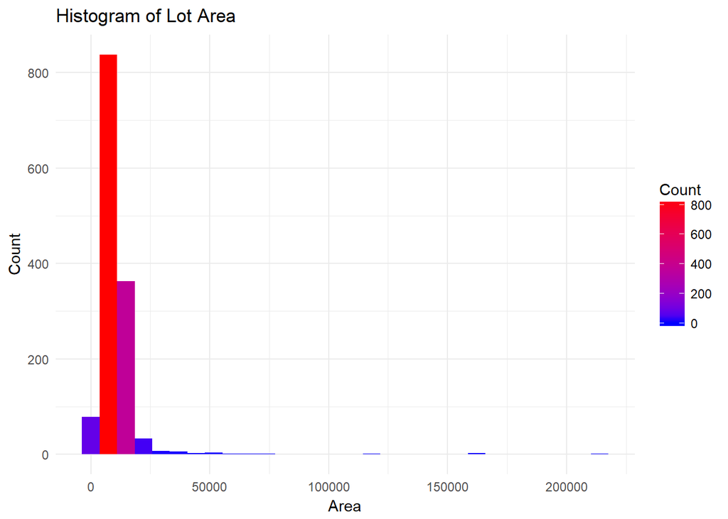

```r
ggplot(data=data_wo_na, aes(LotArea)) +
 geom_histogram(aes(fill = ..count..)) +
 theme_minimal() +
 scale_fill_gradient("Count",low="blue", high="red") +
 labs(x= 'Area', y= 'Count') +
 ggtitle('Histogram of Lot Area')
```

Upon log-transform it is normalized.

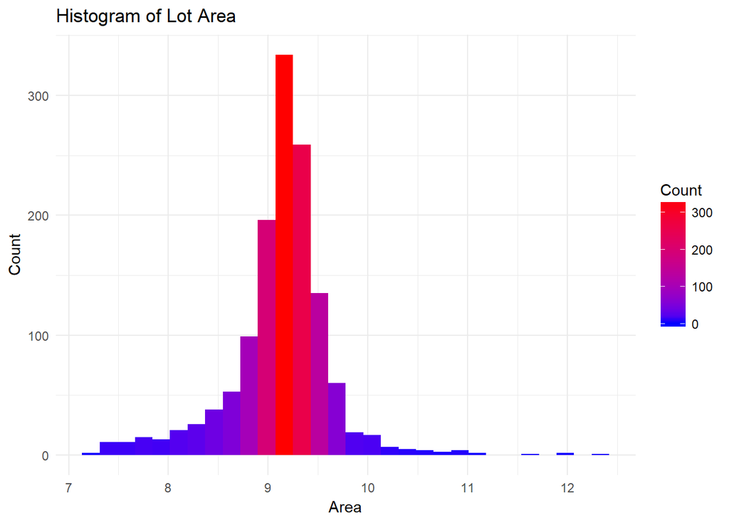

```r
data_wo_na2 <- data_wo_na
data_wo_na2$logLot <- log(data_wo_na$LotArea)
ggplot(data=data_wo_na2, aes(logLot)) +
 geom_histogram(aes(fill = ..count..)) +
 theme_minimal() +
 scale_fill_gradient("Count",low="blue", high="red") +
 labs(x= 'Area', y= 'Count') +
 ggtitle('Histogram of Lot Area')
```

- Overall quality seems to be a good predictor of price:

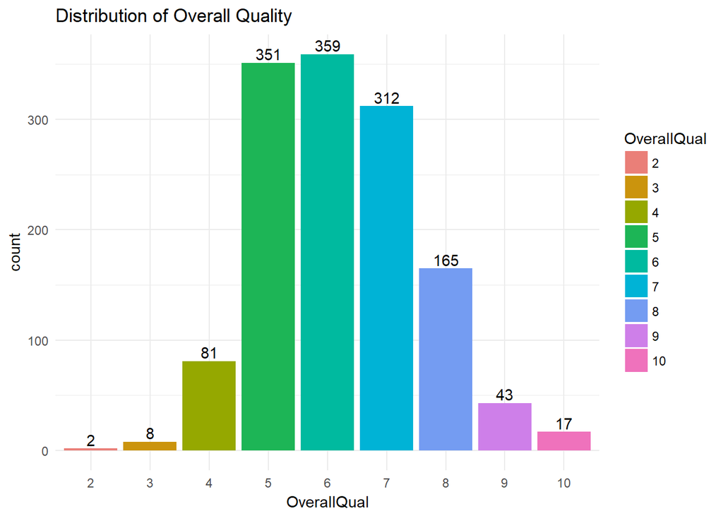

```r
ggplot(data = data_wo_na, aes(x = OverallQual, fill = OverallQual )) +
geom_bar()+
scale_fill_hue(c = 80)+
ggtitle("Distribution of Overall Quality")+
theme_minimal()+
geom_text(stat='count',aes(label=..count..),vjust=-0.25)
```

Unfortunately, we accidentally deleted one of the levels of our one of the most strongest predictor while removing NAs.

- Change in the sale price with quality:

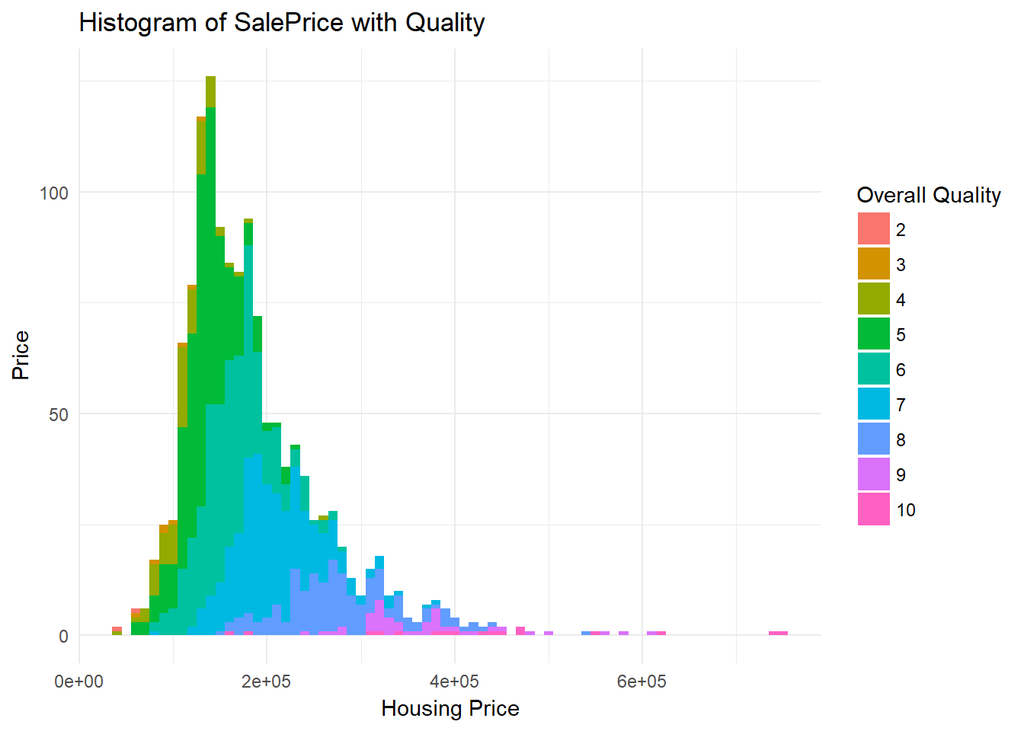

```r
ggplot(data = data_wo_na, aes(x = SalePrice,fill = as.factor(OverallQual))) +
  geom_histogram(position = "stack", binwidth = 10000) +
  ggtitle("Histogram of SalePrice with Quality") +
  ylab("Price") +
  xlab("Housing Price") +
  scale_fill_discrete(name="Overall Quality")+
  theme_minimal()
```

- Correlation matrix of numeric columns:

```r
library(corrplot)
data_wo_na_num <- data_wo_na[,sapply(data_wo_na, is.numeric)]
dim(data_wo_na_num)
```

```
## [1] 1338   33
```

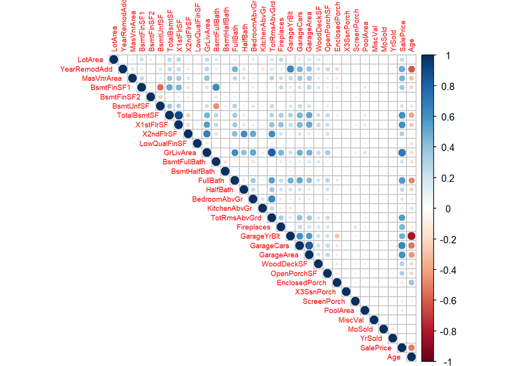

```r
corrplot(round(cor(data_wo_na_num),3),
         method="circle",
         type='upper',
         tl.cex = 0.6)
```

### Data Transformation

#### High Correlations:

- Detail of correlations:

```r
#1
cor(data_wo_na_num$GarageArea,data_wo_na_num$GarageCars)  #0.832
```

```
## [1] 0.8321655
```

```r
cor(data_wo_na_num$SalePrice,data_wo_na_num$GarageArea)  #0.6075
```

```
## [1] 0.6075354
```

```r
cor(data_wo_na_num$SalePrice,data_wo_na_num$GarageCars) #0.6401 Keep it.
```

```
## [1] 0.6401544
```

```r
#2
cor(data_wo_na_num$TotalBsmtSF,data_wo_na_num$X1stFlrSF)  #0.893
```

```
## [1] 0.8931098
```

```r
cor(data_wo_na_num$SalePrice,data_wo_na_num$TotalBsmtSF)  #0.602
```

```
## [1] 0.6020423
```

```r
cor(data_wo_na_num$SalePrice,data_wo_na_num$X1stFlrSF) # 0.6047 Keep it.
```

```
## [1] 0.6047145
```

```r
#3

cor(data_wo_na_num$Age,data_wo_na_num$GarageYrBlt)  #0.825
```

```
## [1] -0.8251724
```

```r
cor(data_wo_na_num$SalePrice,data_wo_na_num$Age)  #0.504 Keep it.
```

```
## [1] -0.5042972
```

```r
cor(data_wo_na_num$SalePrice,data_wo_na_num$GarageYrBlt) # 0.481
```

```
## [1] 0.4817298
```

```r
#4

cor(data_wo_na_num$GrLivArea,data_wo_na_num$TotRmsAbvGrd)  #0.823
```

```
## [1] 0.8234912
```

```r
cor(data_wo_na_num$SalePrice,data_wo_na_num$GrLivArea)  # 0.7117 Keep it.
```

```
## [1] 0.7117062
```

```r
cor(data_wo_na_num$SalePrice,data_wo_na_num$TotRmsAbvGrd) # 0.5518
```

```
## [1] 0.5518207
```

```r
#Summary of PoolArea:
summary(data_wo_na$PoolArea) # Distribution is useless.
```

```
##    Min. 1st Qu.  Median    Mean 3rd Qu.    Max.
##    0.00    0.00    0.00    3.01    0.00  738.00
```

```r
#Summary of Month-Sold:
summary(data_wo_na$MoSold) # useless.
```

```
##    Min. 1st Qu.  Median    Mean 3rd Qu.    Max.
##   1.000   5.000   6.000   6.332   8.000  12.000
```

```r
data_wo_na <- data_wo_na[ ,(!names(data_wo_na) %in% c('GarageArea','TotalBsmtSF','GarageYrBlt','TotRmsAbvGrd','PoolArea','MoSold'))]

dim(data_wo_na)
```

```
## [1] 1338   69
```

Due to high correlation ratios, we dropped some columns. 69 Columns are left after cleaning of NA and highly correlated numeric columns. We also drop PoolArea and MoSold columns which have meaningless distribution.

#### Fix Skeweness & Normalization

- Fix skeweness with log transform:
- Fix skeweness with log transform and apply standardize the numerical columns:

```r
library(e1071)
library(dplyr)

colClass <- sapply(data_wo_na, class)  # list of columns and datatype pairs.

# log transformation
deskew <- function(x){
  if (abs(skewness(x)) > 0.5){
    x <- log(1+x)
  }
  x
}

# normalization
rescale <- function(x) { (x-mean(x))/sd(x) }

numericCols <- names(colClass[colClass == "integer" | colClass == "numeric"])

data_wo_na <- data_wo_na %>% mutate_at(.vars=numericCols, funs(deskew)) %>% mutate_at(.vars=numericCols, funs(rescale))
data_wo_na_num <- data_wo_na[,sapply(data_wo_na, is.numeric)]
dim(data_wo_na)
```

```
## [1] 1338   69
```

- After transformation; check correlation matrix:

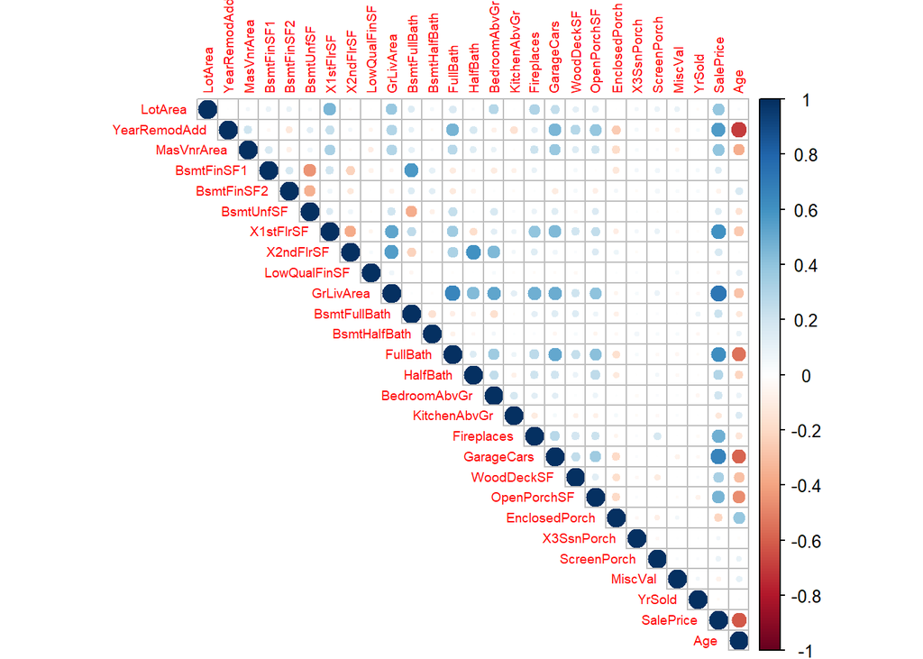

```r
corrplot(round(cor(data_wo_na_num),3),
         method="circle",
         type='upper',
         tl.cex = 0.6)
```

### Feature Selection

#### Subset Selection

- Subset selection with transformed numeric columns:

```r
#Search best predictors in numeric columns
library(leaps)
set.seed(1)
#Create set from numeric columns
train_num <- data_wo_na_num[,sapply(data_wo_na_num, is.numeric)]
dim(train_num)
```

```
## [1] 1338   27
```

```r
train_num <- train_num[ ,(!names(train_num) %in% c('flag'))]
#test_num <- test[,sapply(data_wo_na_num, is.numeric)]


best.subset <- regsubsets(data_wo_na_num$SalePrice~., train_num, nvmax=50)
best.subset.summary <- summary(best.subset)
m <- best.subset.summary$outmat
#best.subset.summary$outmat[30:31,]


#Adjusted R Squared
best.subset.by.adjr2 <- which.max(best.subset.summary$adjr2)  #16
#names(best.subset.summary)
which(m[16,]=='*')
```

```
##       LotArea  YearRemodAdd    BsmtFinSF1    BsmtFinSF2     X2ndFlrSF
##             1             2             4             5             8
##  LowQualFinSF     GrLivArea  BsmtFullBath  BedroomAbvGr  KitchenAbvGr
##             9            10            11            15            16
##    Fireplaces    GarageCars    WoodDeckSF EnclosedPorch   ScreenPorch
##            17            18            19            21            23
##           Age
##            26
```

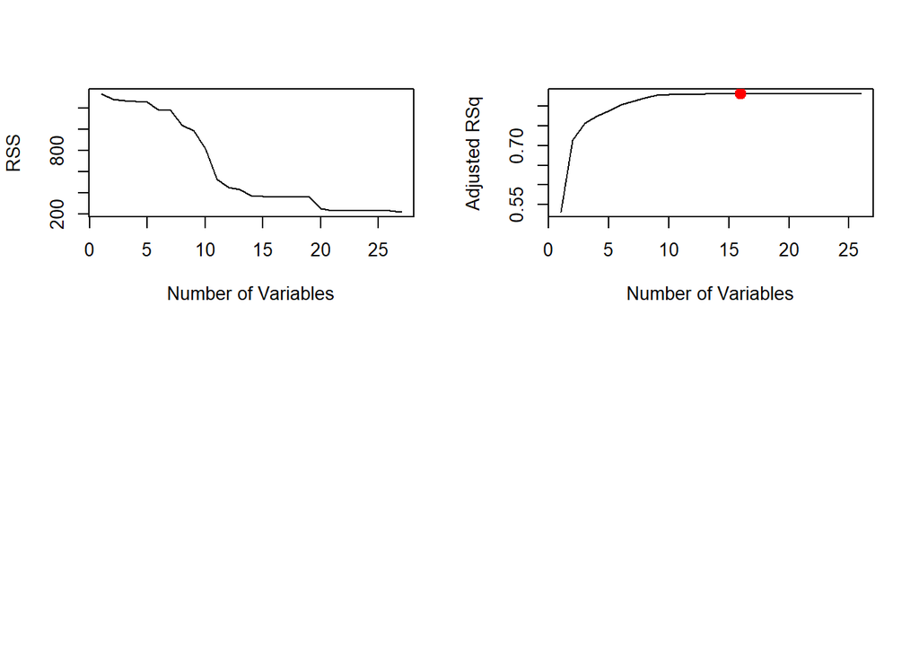

```r
#Plot
par(mfrow=c(2,2))
plot(best.subset$rss, xlab="Number of Variables", ylab="RSS", type="l")
plot(best.subset.summary$adjr2, xlab="Number of Variables", ylab="Adjusted RSq", type="l")
points(best.subset.by.adjr2, best.subset.summary$adjr2[best.subset.by.adjr2], col="red", cex =2, pch =20)



# #old:
# LotArea + YearBuilt + YearRemodAdd + +BsmtFinSF2 + X2ndFlrSF + LowQualFinSF + GrLivArea + BsmtFullBath +
#   + FullBath + BedroomAbvGr + KitchenAbvGr + Fireplaces + GarageCars + WoodDeckSF + OpenPorchSF + EnclosedPorch +
#   ScreenPorch + PoolArea + MiscVal + YrSold
#
# #new:
# LotArea +  YearRemodAdd + BsmtFinSF1 + X2ndFlrSF + LowQualFinSF + GrLivArea + BsmtFullBath +
#  + BedroomAbvGr + KitchenAbvGr + Fireplaces + GarageCars + WoodDeckSF  + EnclosedPorch +
#   ScreenPorch + Age
```

## Modeling

### 1. Regression Models

#### 1.1. Linear Regression

```r
train_num_fixed <- data_wo_na%>% filter(data_wo_na$flag ==1)
train_num_fixed <- train_num_fixed[,sapply(train_num_fixed,is.numeric)]


dim(train_num_fixed)
```

```
## [1] 915  27
```

```r
test_num_fixed <- data_wo_na%>% filter(data_wo_na$flag ==0)
test_num_fixed <- test_num_fixed[,sapply(test_num_fixed,is.numeric)]

#Linear Regression with 17 predictors
library(boot)

set.seed(88)
glm.fit=glm(SalePrice~.,data=train_num_fixed)


cv.error=cv.glm(train_num_fixed,glm.fit,K=10)$delta[1]
cv.error
```

```
## [1] 0.1668795
```

```r
# 0.1194035

summary(glm.fit)
```

```
##
## Call:
## glm(formula = SalePrice ~ ., data = train_num_fixed)
##
## Deviance Residuals:
##     Min       1Q   Median       3Q      Max
## -3.2549  -0.1938   0.0075   0.2193   1.3246
##
## Coefficients:
##                Estimate Std. Error t value Pr(>|t|)
## (Intercept)    0.011339   0.013228   0.857  0.39156
## LotArea        0.129535   0.016232   7.980 4.50e-15 ***
## YearRemodAdd   0.164585   0.019163   8.589  < 2e-16 ***
## MasVnrArea     0.018384   0.015486   1.187  0.23548
## BsmtFinSF1     0.095432   0.018362   5.197 2.51e-07 ***
## BsmtFinSF2    -0.001873   0.014695  -0.127  0.89859
## BsmtUnfSF      0.022415   0.017226   1.301  0.19352
## X1stFlrSF      0.109393   0.056489   1.937  0.05312 .
## X2ndFlrSF     -0.026701   0.057488  -0.464  0.64243
## LowQualFinSF  -0.008839   0.013596  -0.650  0.51580
## GrLivArea      0.433317   0.069101   6.271 5.60e-10 ***
## BsmtFullBath   0.050432   0.018711   2.695  0.00717 **
## BsmtHalfBath   0.007828   0.014368   0.545  0.58602
## FullBath       0.039560   0.023498   1.683  0.09263 .
## HalfBath       0.022400   0.020097   1.115  0.26531
## BedroomAbvGr  -0.046696   0.018110  -2.578  0.01009 *
## KitchenAbvGr  -0.089302   0.014482  -6.166 1.06e-09 ***
## Fireplaces     0.073135   0.016388   4.463 9.14e-06 ***
## GarageCars     0.112880   0.019399   5.819 8.27e-09 ***
## WoodDeckSF     0.021856   0.014667   1.490  0.13653
## OpenPorchSF    0.011595   0.016082   0.721  0.47108
## EnclosedPorch  0.010196   0.015027   0.679  0.49763
## X3SsnPorch    -0.004401   0.012913  -0.341  0.73331
## ScreenPorch    0.041994   0.013946   3.011  0.00268 **
## MiscVal       -0.015761   0.012900  -1.222  0.22213
## YrSold        -0.017324   0.013386  -1.294  0.19595
## Age           -0.219840   0.025646  -8.572  < 2e-16 ***
## ---
## Signif. codes:  0 '***' 0.001 '**' 0.01 '*' 0.05 '.' 0.1 ' ' 1
##
## (Dispersion parameter for gaussian family taken to be 0.1588116)
##
##     Null deviance: 950.94  on 914  degrees of freedom
## Residual deviance: 141.02  on 888  degrees of freedom
## AIC: 941.62
##
## Number of Fisher Scoring iterations: 2
```

```r
glm.predicted=predict(glm.fit,test_num_fixed)

mean((glm.predicted-test_num_fixed$SalePrice)^2)
```

```
## [1] 0.1993836
```

```r
# 36695352395

#R squared
1-(glm.fit$deviance/glm.fit$null.deviance)
```

```
## [1] 0.8516996
```

```r
#0.8860795


# full numeric columns: 0.8516
# subset selected columns: 0.8493
```

- For linear regression model with all transformed numeric columns; accuracy is 0.8516. For columns via subset selection, it is 0.8493.

#### 1.2 Extreme Gradient Boosting Model

```r
# XG Boost
library("xgboost")
library("caret")
#Prepare data  for model
train_selected=train_num_fixed[c("LotArea","YearRemodAdd","BsmtFinSF1","X2ndFlrSF","LowQualFinSF","GrLivArea","BsmtFullBath",
                                 "BedroomAbvGr","KitchenAbvGr","Fireplaces","GarageCars","WoodDeckSF","EnclosedPorch","ScreenPorch","Age")]

test_selected=test_num_fixed[c("LotArea","YearRemodAdd","BsmtFinSF1","X2ndFlrSF","LowQualFinSF","GrLivArea","BsmtFullBath",
                                 "BedroomAbvGr","KitchenAbvGr","Fireplaces","GarageCars","WoodDeckSF","EnclosedPorch","ScreenPorch","Age")]
#
# train_num_fixed <- data_wo_na%>% filter(data_wo_na$flag ==1)
# train_num_fixed <- train_num_fixed[,sapply(train_num_fixed,is.numeric)]
#
# test_num_fixed <- data_wo_na%>% filter(data_wo_na$flag ==0)
# test_num_fixed <- test_num_fixed[,sapply(test_num_fixed,is.numeric)]

xgbtrain <- model.matrix(~.+0,data = train_selected)
xgbtest <- model.matrix(~.+0,data = test_selected)



m_train <- xgb.DMatrix(data = xgbtrain,label=train_num_fixed$SalePrice)
m_test <- xgb.DMatrix(data = xgbtest,label=test_num_fixed$SalePrice)


#Cross Validation

#Set Parameters
params <- list(booster = "gblinear", objective = "reg:linear",
               eta=0.1, gamma=0, max_depth=1, min_child_weight=1,
               subsample=1, colsample_bytree=1, eval_metric="rmse")

set.seed(88)
xgbcv <- xgb.cv( params = params, data = m_train, nrounds = 10000,
                 nfold = 10, showsd = T, stratified = T,
                 print_every_n = 10, early_stopping_rounds = 20, maximize = F)
```

```
## Multiple eval metrics are present. Will use test_rmse for early stopping.
## Will train until test_rmse hasn't improved in 20 rounds.
##
## Stopping. Best iteration:
```

```r
#Best iteration results
xgbcv$best_iteration
```

```
## [1] 281
```

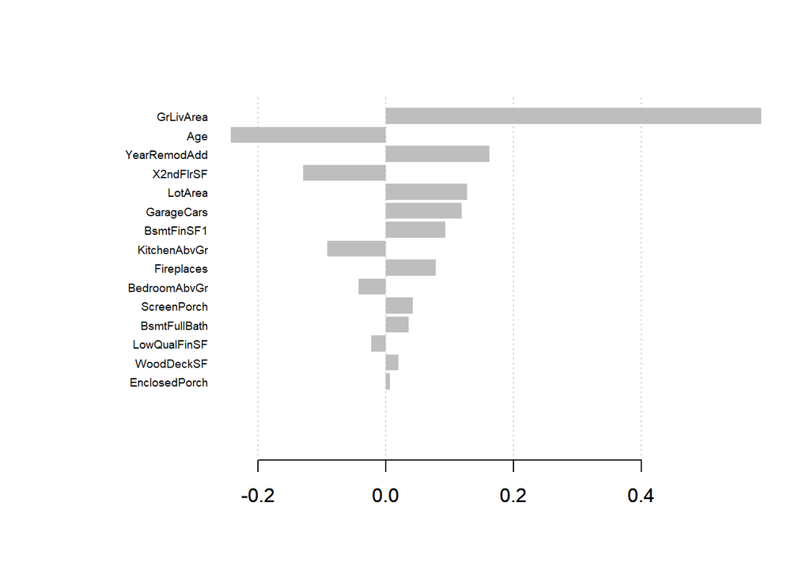

```r
#Train with best iteration round

xgb1 <- xgb.train (params = params, data = m_train,
                   nrounds = xgbcv$best_iteration)

xgbpred <- predict (xgb1,m_test)

#mean((xgbpred-test$SalePrice)^2)

#Plot importance graph
mat <- xgb.importance (feature_names = colnames(m_train),model = xgb1)
xgb.plot.importance (importance_matrix = mat[1:18])
```

```r
#Grid search
set.seed(88)

xgbGrid <-  expand.grid(nrounds = c(67,68,69),
                        max_depth = c(2,3,4),
                        eta = c(0.2),
                        gamma = 0, colsample_bytree=c(0.9),
                        min_child_weight=c(0.5,0.6), subsample=c(0.8))



fitControl <- trainControl(method = "repeatedcv",number = 2, repeats = 1)

xgbFit_gridsearch <- train(xgbtrain, train_num_fixed$SalePrice,  method = "xgbTree",
                trControl = fitControl, verbose = T,
                tuneGrid = xgbGrid)
#Max R Squared Value
max(xgbFit_gridsearch$results["Rsquared"])
```

```
## [1] 0.8323507
```

```r
#xgbFit_gridsearch$results[order(-xgbFit_gridsearch$results["Rsquared"]),]
```

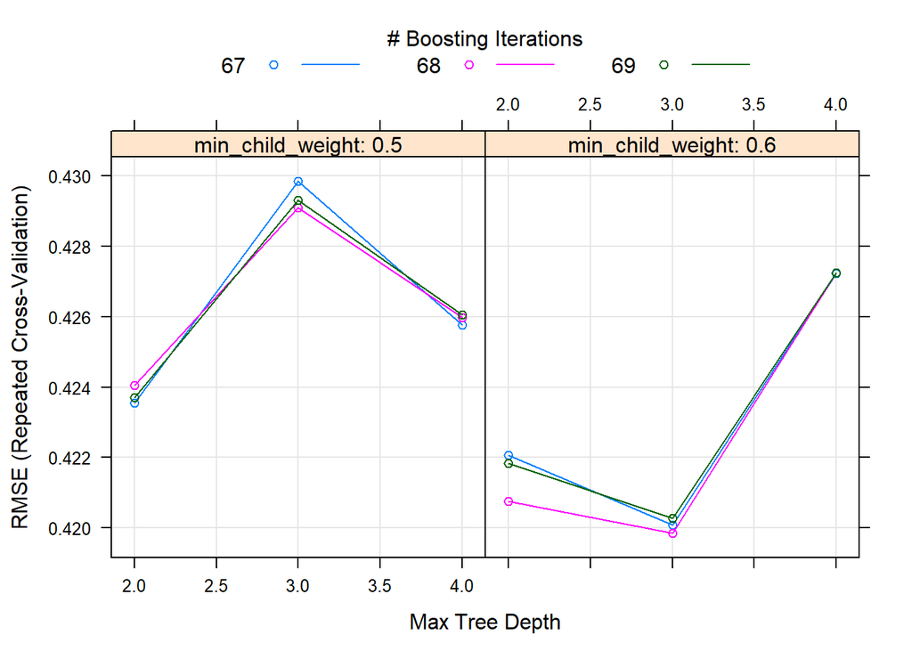

```r
#Plot grid search performance
plot(xgbFit_gridsearch)
```

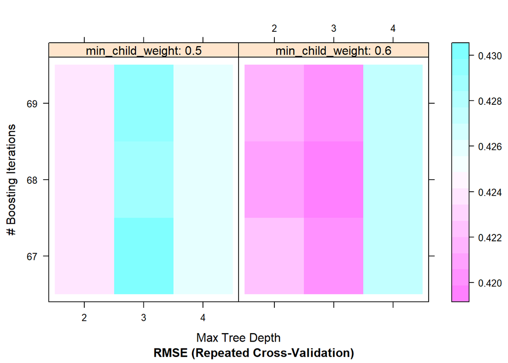

```r
#Plot levels
plot(xgbFit_gridsearch, plotType = "level")
```

```r
#Predict
xgbpred_gridsearch <- predict (xgbFit_gridsearch,xgbtest)

#Mean error between predicted vs. actual
mean((xgbpred_gridsearch-test_num_fixed$SalePrice)^2)
```

```
## [1] 0.1605483
```

- MSE is 0.16054 when the best model generated by Grid Search parameter tuning method.

### 2. Classification Models

#### 2.1. Logistic Regression

- Convert numeric SalePrice column into two categories. Prices over median value are tagged as *1*, prices lower than the median are labeled as *0*

```r
#attach(Boston)
#Boston
data2 <- data_wo_na  #data2 ve data_wo_na temizlenmis, scale edilmis variable'lar.
#dim(boston)

data2$SalePrice <- ifelse(data2$SalePrice>=median(data2$SalePrice),1, 0) #bigger than median or not. (convert cat variable!)
data2$SalePrice <- as.factor(data2$SalePrice)

summary(data2)
```

```
##    MSSubClass     MSZoning       LotArea          Street     LotShape
##  20     :502   C (all):   8   Min.   :-3.78749   Grvl:   5   IR1:459
##  60     :294   FV     :  62   1st Qu.:-0.33368   Pave:1333   IR2: 40
##  50     :129   RH     :  11   Median : 0.08223               IR3: 10
##  120    : 86   RL     :1066   Mean   : 0.00000               Reg:829
##  160    : 61   RM     : 191   3rd Qu.: 0.47522
##  70     : 57                  Max.   : 6.10328
##  (Other):209
##  LandContour  Utilities      LotConfig   LandSlope   Neighborhood
##  Bnk:  52    AllPub:1337   Corner :244   Gtl:1265   NAmes  :209
##  HLS:  48    NoSeWa:   1   CulDSac: 90   Mod:  61   CollgCr:146
##  Low:  32                  FR2    : 43   Sev:  12   OldTown:100
##  Lvl:1206                  FR3    :  4              Somerst: 83
##                            Inside :957              Gilbert: 77
##                                                     NridgHt: 75
##                                                     (Other):648
##    Condition1     Condition2     BldgType      HouseStyle   OverallQual
##  Norm   :1162   Norm   :1324   1Fam  :1138   1Story :657   6      :359
##  Feedr  :  63   Feedr  :   5   2fmCon:  22   2Story :426   5      :351
##  Artery :  43   Artery :   2   Duplex:  28   1.5Fin :134   7      :312
##  RRAn   :  26   PosN   :   2   Twnhs :  38   SLvl   : 64   8      :165
##  PosN   :  19   RRNn   :   2   TwnhsE: 112   SFoyer : 30   4      : 81
##  RRAe   :  10   PosA   :   1                 1.5Unf : 11   9      : 43
##  (Other):  15   (Other):   2                 (Other): 16   (Other): 27
##   OverallCond   YearRemodAdd       RoofStyle       RoofMatl
##  5      :770   Min.   :-1.7630   Flat   :  11   CompShg:1314
##  6      :233   1st Qu.:-0.8668   Gable  :1037   Tar&Grv:   9
##  7      :183   Median : 0.4380   Gambrel:  10   WdShngl:   6
##  8      : 68   Mean   : 0.0000   Hip    : 272   WdShake:   5
##  4      : 46   3rd Qu.: 0.9015   Mansard:   6   Membran:   1
##  9      : 20   Max.   : 1.1931   Shed   :   2   Metal  :   1
##  (Other): 18                                    (Other):   2
##   Exterior1st   Exterior2nd    MasVnrType    MasVnrArea      ExterQual
##  VinylSd:486   VinylSd:475   BrkCmn : 15   Min.   :-0.8518   Ex: 51
##  HdBoard:211   HdBoard:197   BrkFace:432   1st Qu.:-0.8518   Fa:  7
##  MetalSd:201   MetalSd:197   None   :763   Median :-0.8518   Gd:477
##  Wd Sdng:183   Wd Sdng:176   Stone  :128   Mean   : 0.0000   TA:803
##  Plywood:100   Plywood:127                 3rd Qu.: 1.0927
##  CemntBd: 52   CmentBd: 51                 Max.   : 1.9260
##  (Other):105   (Other):115
```

[output cut: 65 more lines]

```
##  Min.   :-0.3069   Min.   :-0.189   Min.   :-1.3569   WD     :1158
##  1st Qu.:-0.3069   1st Qu.:-0.189   1st Qu.:-0.6055   New    : 117
##  Median :-0.3069   Median :-0.189   Median : 0.1460   COD    :  42
##  Mean   : 0.0000   Mean   : 0.000   Mean   : 0.0000   ConLD  :   6
##  3rd Qu.:-0.3069   3rd Qu.:-0.189   3rd Qu.: 0.8975   ConLI  :   4
##  Max.   : 3.9229   Max.   : 7.753   Max.   : 1.6490   ConLw  :   4
##                                                       (Other):   7
##  SaleCondition  SalePrice flag         Age
##  Abnorml:  86   0:667     0:423   Min.   :-1.9370
##  AdjLand:   1   1:671     1:915   1st Qu.:-0.9745
##  Alloca :   7                     Median : 0.2348
##  Family :  20                     Mean   : 0.0000
##  Normal :1104                     3rd Qu.: 0.7652
##  Partial: 120                     Max.   : 1.8641
##
```

```r
dim(data2)
```

```
## [1] 1338   69
```

```r
sum(is.na(data2))
```

```
## [1] 0
```

```r
#data2 SalePrice kategoriye çevrilmiş hali.
```

- *GLM with numeric columns:* Just Numeric columns which offered by best subset selection: (Lineer Reg ile karşılaştırılmalı.)

```r
library(dplyr)

#glimpse(data2)

#fctr <- names(data2)[ sapply(data_wo_na,is.factor)]

##########
#dim(data2)

#head(data2)

train2 <- data2 %>% filter (data2$flag == 1 )
test2 <- data2 %>% filter (data2$flag == 0 )


#dim(train2)


glm.fit=glm(SalePrice~LotArea +  YearRemodAdd + BsmtFinSF1 + X2ndFlrSF + LowQualFinSF + GrLivArea + BsmtFullBath +
 + BedroomAbvGr + KitchenAbvGr + Fireplaces + GarageCars + WoodDeckSF  + EnclosedPorch +
  ScreenPorch + Age,data=train2,family=binomial) #fit

#summary:
summary(glm.fit)
```

```
##
## Call:
## glm(formula = SalePrice ~ LotArea + YearRemodAdd + BsmtFinSF1 +
##     X2ndFlrSF + LowQualFinSF + GrLivArea + BsmtFullBath + +BedroomAbvGr +
##     KitchenAbvGr + Fireplaces + GarageCars + WoodDeckSF + EnclosedPorch +
##     ScreenPorch + Age, family = binomial, data = train2)
##
## Deviance Residuals:
##      Min        1Q    Median        3Q       Max
## -3.04024  -0.17903   0.00072   0.19565   2.97025
##
## Coefficients:
##                Estimate Std. Error z value Pr(>|z|)
## (Intercept)    0.097964   0.145956   0.671 0.502098
## LotArea        0.806141   0.175519   4.593 4.37e-06 ***
## YearRemodAdd   0.519646   0.219784   2.364 0.018062 *
## BsmtFinSF1     0.375202   0.181711   2.065 0.038940 *
## X2ndFlrSF     -0.318441   0.196698  -1.619 0.105462
## LowQualFinSF  -0.124347   0.160674  -0.774 0.438984
## GrLivArea      3.138135   0.362303   8.662  < 2e-16 ***
## BsmtFullBath   0.061140   0.172498   0.354 0.723012
## BedroomAbvGr   0.008292   0.198271   0.042 0.966642
## KitchenAbvGr  -0.535659   0.148980  -3.596 0.000324 ***
## Fireplaces     0.356635   0.166790   2.138 0.032498 *
## GarageCars     0.604000   0.241440   2.502 0.012361 *
## WoodDeckSF     0.291699   0.150349   1.940 0.052361 .
## EnclosedPorch  0.046040   0.170177   0.271 0.786741
## ScreenPorch    0.064925   0.135674   0.479 0.632267
## Age           -1.804258   0.268747  -6.714 1.90e-11 ***
## ---
## Signif. codes:  0 '***' 0.001 '**' 0.01 '*' 0.05 '.' 0.1 ' ' 1
##
## (Dispersion parameter for binomial family taken to be 1)
##
##     Null deviance: 1268.43  on 914  degrees of freedom
## Residual deviance:  342.65  on 899  degrees of freedom
## AIC: 374.65
##
## Number of Fisher Scoring iterations: 7
```

```r
coef(glm.fit)
```

```
##   (Intercept)       LotArea  YearRemodAdd    BsmtFinSF1     X2ndFlrSF
##   0.097964250   0.806141102   0.519646165   0.375201927  -0.318441177
##  LowQualFinSF     GrLivArea  BsmtFullBath  BedroomAbvGr  KitchenAbvGr
##  -0.124347362   3.138135287   0.061139637   0.008291645  -0.535658820
##    Fireplaces    GarageCars    WoodDeckSF EnclosedPorch   ScreenPorch
##   0.356634870   0.604000471   0.291699241   0.046040403   0.064925135
##           Age
##  -1.804258486
```

```r
#Conf.Matrix:
glm.probs=predict(glm.fit,train2,type="response")
#length(glm.probs)

glm.pred=rep(0,length(glm.probs))
glm.pred[glm.probs>.5]=1

table(glm.pred,train2$SalePrice)
```

```
##
## glm.pred   0   1
##        0 420  36
##        1  35 424
```

```r
#Test setinde yeni kategoriler olduğu için çalışmadı.

#Conf.Matrix:
glm.probs=predict(glm.fit,test2,type="response")
#length(glm.probs)

glm.pred=rep(0,length(glm.probs))
glm.pred[glm.probs>.5]=1

table(glm.pred,test2$SalePrice)
```

```
##
## glm.pred   0   1
##        0 185  22
##        1  27 189
```

```r
(185+189) / (185+189+27+22) #0.884
```

```
## [1] 0.8841608
```

```r
#RSquared / Adjusted R Squared:
library(rsq)
rsq(glm.fit)
```

```
## [1] 0.7719257
```

```r
rsq(glm.fit,adj=TRUE)
```

```
## [1] 0.7681202
```

```r
#mse:
mean(glm.fit$residuals^2)
```

```
## [1] 26.1886
```

```r
##Evaluation Metrics:
Accuracy(glm.pred, test2$SalePrice) #0.8841608
```

```
## [1] 0.8841608
```

```r
AUC(glm.pred, test2$SalePrice) #0.8841881
```

```
## [1] 0.8841881
```

```r
F1_Score(glm.pred, test2$SalePrice, positive = NULL) #0.8830549
```

```
## [1] 0.8830549
```

```r
ConfusionMatrix(glm.pred, test2$SalePrice)
```

```
##       y_pred
## y_true   0   1
##      0 185  27
##      1  22 189
```

- *GLM with numeric columns + one hot encoded categorical columns:*
- Create dummy variables:

```r
library(dummies)
library(dplyr)

dim(data_wo_na)
```

```
## [1] 1338   69
```

```r
#data_wo_na <- data_wo_na[ ,(!names(data_wo_na) %in% c('GarageArea','TotalBsmtSF','GarageYrBlt','TotRmsAbvGrd'))]


fctr <- names(data_wo_na)[ sapply(data_wo_na,is.factor)]
fctr <- fctr[1:length(fctr)-1]


data_Temp <- data_wo_na

new_combi <- dummy.data.frame(data_Temp, names = fctr,sep = '_')

glimpse(new_combi$flag)
```

```
##  Factor w/ 2 levels "0","1": 2 2 2 2 2 2 2 2 2 2 ...
```

```r
dim(new_combi) # 1338  289
```

```
## [1] 1338  289
```

```r
names(new_combi)  #dummyli hali new_combi
```

```
##   [1] "MSSubClass_20"         "MSSubClass_30"
##   [3] "MSSubClass_40"         "MSSubClass_45"
##   [5] "MSSubClass_50"         "MSSubClass_60"
##   [7] "MSSubClass_70"         "MSSubClass_75"
##   [9] "MSSubClass_80"         "MSSubClass_85"
##  [11] "MSSubClass_90"         "MSSubClass_120"
##  [13] "MSSubClass_160"        "MSSubClass_180"
##  [15] "MSSubClass_190"        "MSZoning_C (all)"
##  [17] "MSZoning_FV"           "MSZoning_RH"
##  [19] "MSZoning_RL"           "MSZoning_RM"
##  [21] "LotArea"               "Street_Grvl"
##  [23] "Street_Pave"           "LotShape_IR1"
##  [25] "LotShape_IR2"          "LotShape_IR3"
##  [27] "LotShape_Reg"          "LandContour_Bnk"
##  [29] "LandContour_HLS"       "LandContour_Low"
```

[output cut: 130 more lines]

```r
#attach(Boston)
#Boston
data2 <- new_combi
#dim(boston)

data2$Price <- ifelse(data2$SalePrice>=median(data2$SalePrice),1, 0) #bigger than median or not. (convert cat variable!)

dim(data2)  #1338  289
```

```
## [1] 1338  290
```

```r
sum(is.na(data2))
```

```
## [1] 0
```

- All numeric columns and dummy variables:

```r
library(dplyr)


train2 <- data2 %>% filter (data2$flag == 1 )
test2 <- data2 %>% filter (data2$flag == 0 )

train2 <- train2[ ,(!names(train2) %in% c('flag','SalePrice'))]
test2 <- test2[ ,(!names(test2) %in% c('flag','SalePrice'))]


#dim(train2)


glm.fit=glm(Price~.,data=train2,family=binomial) #fit

#summary:
summary(glm.fit)
```

```
##
## Call:
## glm(formula = Price ~ ., family = binomial, data = train2)
##
## Deviance Residuals:
##        Min          1Q      Median          3Q         Max
## -6.881e-05  -2.100e-08   2.100e-08   2.100e-08   6.487e-05
##
## Coefficients: (55 not defined because of singularities)
##                         Estimate Std. Error z value Pr(>|z|)
## (Intercept)            7.644e+10  6.788e+17   0.000    1.000
## MSSubClass_20          1.639e+02  1.366e+06   0.000    1.000
## MSSubClass_30          1.843e+02  1.481e+06   0.000    1.000
## MSSubClass_40          1.771e+02  1.567e+06   0.000    1.000
## MSSubClass_45          2.083e+02  4.748e+07   0.000    1.000
## MSSubClass_50          3.815e+01  1.543e+06   0.000    1.000
## MSSubClass_60          2.751e+02  1.338e+06   0.000    1.000
## MSSubClass_70          1.655e+02  1.378e+06   0.000    1.000
## MSSubClass_75          2.280e+02  2.503e+06   0.000    1.000
## MSSubClass_80          2.368e+02  4.748e+07   0.000    1.000
## MSSubClass_85          7.880e+01  1.457e+06   0.000    1.000
## MSSubClass_90          2.331e+02  1.843e+06   0.000    1.000
## MSSubClass_120         2.283e+02  1.726e+06   0.000    1.000
## MSSubClass_160         2.498e+02  1.693e+06   0.000    1.000
## MSSubClass_180         2.271e+02  4.749e+07   0.000    1.000
## MSSubClass_190                NA         NA      NA       NA
## `MSZoning_C (all)`     1.194e+02  1.825e+06   0.000    1.000
## MSZoning_FV            9.554e+01  3.973e+05   0.000    1.000
## MSZoning_RH            3.792e-01  5.197e+05   0.000    1.000
## MSZoning_RL           -1.007e+01  1.170e+05   0.000    1.000
## MSZoning_RM                   NA         NA      NA       NA
## LotArea                1.773e+01  4.847e+04   0.000    1.000
## Street_Grvl           -2.811e+02  1.039e+06   0.000    1.000
## Street_Pave                   NA         NA      NA       NA
## LotShape_IR1          -3.750e+01  4.860e+04  -0.001    0.999
## LotShape_IR2          -1.792e+01  1.291e+05   0.000    1.000
## LotShape_IR3          -2.123e+02  2.567e+05  -0.001    0.999
## LotShape_Reg                  NA         NA      NA       NA
## LandContour_Bnk        4.936e+00  1.778e+05   0.000    1.000
## LandContour_HLS       -2.037e+01  1.267e+05   0.000    1.000
```

[output cut: 251 more lines]

```
## SaleCondition_Abnorml  9.618e+01  4.892e+05   0.000    1.000
## SaleCondition_AdjLand  2.976e+02  6.422e+05   0.000    1.000
## SaleCondition_Alloca   6.588e+01  2.015e+06   0.000    1.000
## SaleCondition_Family   1.470e+02  4.239e+05   0.000    1.000
## SaleCondition_Normal   1.630e+02  4.773e+05   0.000    1.000
## SaleCondition_Partial         NA         NA      NA       NA
## Age                   -3.584e+01  7.170e+04   0.000    1.000
##
## (Dispersion parameter for binomial family taken to be 1)
##
##     Null deviance: 1.2684e+03  on 914  degrees of freedom
## Residual deviance: 1.0279e-07  on 682  degrees of freedom
## AIC: 466
##
## Number of Fisher Scoring iterations: 25
```

```r
coef(glm.fit)
```

```
##           (Intercept)         MSSubClass_20         MSSubClass_30
##          7.643892e+10          1.639308e+02          1.842723e+02
##         MSSubClass_40         MSSubClass_45         MSSubClass_50
##          1.770698e+02          2.082602e+02          3.815127e+01
##         MSSubClass_60         MSSubClass_70         MSSubClass_75
##          2.750673e+02          1.654617e+02          2.280446e+02
##         MSSubClass_80         MSSubClass_85         MSSubClass_90
##          2.367695e+02          7.880183e+01          2.330925e+02
##        MSSubClass_120        MSSubClass_160        MSSubClass_180
##          2.283280e+02          2.498313e+02          2.270779e+02
##        MSSubClass_190    `MSZoning_C (all)`           MSZoning_FV
##                    NA          1.193795e+02          9.554360e+01
##           MSZoning_RH           MSZoning_RL           MSZoning_RM
##          3.791525e-01         -1.007174e+01                    NA
##               LotArea           Street_Grvl           Street_Pave
##          1.772500e+01         -2.811370e+02                    NA
##          LotShape_IR1          LotShape_IR2          LotShape_IR3
##         -3.750464e+01         -1.792436e+01         -2.122567e+02
##          LotShape_Reg       LandContour_Bnk       LandContour_HLS
##                    NA          4.935494e+00         -2.036696e+01
##       LandContour_Low       LandContour_Lvl      Utilities_AllPub
##          1.055308e+00                    NA          6.728819e+01
##      Utilities_NoSeWa      LotConfig_Corner     LotConfig_CulDSac
##                    NA          5.004304e-01          2.848899e+01
##         LotConfig_FR2         LotConfig_FR3      LotConfig_Inside
##         -2.288984e+01         -1.048784e+02                    NA
##         LandSlope_Gtl         LandSlope_Mod         LandSlope_Sev
##          4.326266e+00          2.205950e+00                    NA
##  Neighborhood_Blmngtn  Neighborhood_Blueste   Neighborhood_BrDale
##         -1.362728e+01          1.318445e+02          1.148539e+02
##  Neighborhood_BrkSide  Neighborhood_ClearCr  Neighborhood_CollgCr
##         -1.972718e+00         -1.535860e+01         -5.051101e+01
##  Neighborhood_Crawfor  Neighborhood_Edwards  Neighborhood_Gilbert
##          4.423063e+01         -7.372166e+01         -3.585652e+00
##   Neighborhood_IDOTRR  Neighborhood_MeadowV  Neighborhood_Mitchel
##          7.309369e+00         -1.392569e+01         -3.956333e+01
##    Neighborhood_NAmes  Neighborhood_NoRidge  Neighborhood_NPkVill
##         -7.211725e+01         -1.178485e+02          1.350659e+02
##  Neighborhood_NridgHt   Neighborhood_NWAmes  Neighborhood_OldTown
##          7.099911e+00         -2.572758e+01         -1.094314e+02
```

[output cut: 137 more lines]

```
##                    NA          1.702040e+00          7.538445e+00
##         EnclosedPorch            X3SsnPorch           ScreenPorch
##          3.342875e+00          1.790734e+01          1.762495e+00
##               MiscVal                YrSold          SaleType_COD
##          6.735030e+00          7.112192e+00         -7.834066e+01
##          SaleType_Con        SaleType_ConLD        SaleType_ConLI
##         -9.405093e+01          1.190159e+02          3.025798e+00
##        SaleType_ConLw          SaleType_CWD          SaleType_New
##         -9.617367e+01         -2.481158e+00          1.525321e+02
##          SaleType_Oth           SaleType_WD SaleCondition_Abnorml
##                    NA                    NA          9.617830e+01
## SaleCondition_AdjLand  SaleCondition_Alloca  SaleCondition_Family
##          2.975936e+02          6.587886e+01          1.470154e+02
##  SaleCondition_Normal SaleCondition_Partial                   Age
##          1.629630e+02                    NA         -3.583694e+01
```

```r
#Conf.Matrix:
glm.probs=predict(glm.fit,train2,type="response")
#length(glm.probs)

glm.pred=rep(0,length(glm.probs))
glm.pred[glm.probs>.5]=1

table(glm.pred,train2$Price)
```

```
##
## glm.pred   0   1
##        0 455   0
##        1   0 460
```

```r
#Test setinde yeni kategoriler olduğu için çalışmadı.

#Conf.Matrix:
glm.probs=predict(glm.fit,test2,type="response")
#length(glm.probs)

glm.pred=rep(0,length(glm.probs))
glm.pred[glm.probs>.5]=1

table(glm.pred,test2$Price)
```

```
##
## glm.pred   0   1
##        0 173  31
##        1  39 180
```

```r
(173+180) / (173+180+40+30)  # 0.834
```

```
## [1] 0.8345154
```

```r
#RSquared / Adjusted R Squared:
library(rsq)
rsq(glm.fit)
```

```
## [1] 1
```

```r
rsq(glm.fit,adj=TRUE)
```

```
## [1] 1
```

```r
#mse:
mean(glm.fit$residuals^2)
```

```
## [1] 1
```

```r
##Evaluation Metrics:
Accuracy(glm.pred, test2$Price) #0.8345154
```

```
## [1] 0.8345154
```

```r
AUC(glm.pred, test2$Price) #0.8345592
```

```
## [1] 0.8345592
```

```r
F1_Score(glm.pred, test2$Price, positive = NULL) #0.8317308
```

```
## [1] 0.8317308
```

```r
ConfusionMatrix(glm.pred, test2$Price)
```

```
##       y_pred
## y_true   0   1
##      0 173  39
##      1  31 180
```

#### 2.2. Decision Tree

- Numeric coloumnlı Logistic ile ve Decision Tree ile karşılaştırılmalı.

```r
library(tree)
library(ISLR)
dim(data_wo_na)
```

```
## [1] 1338   69
```

```r
data_tree <- data_wo_na

dim(data_tree)
```

```
## [1] 1338   69
```

```r
glimpse(data_tree)
```

```
## Observations: 1,338
## Variables: 69
## $ MSSubClass    <fctr> 60, 20, 60, 70, 60, 50, 20, 60, 50, 190, 20, 60...
## $ MSZoning      <fctr> RL, RL, RL, RL, RL, RL, RL, RL, RM, RL, RL, RL,...
## $ LotArea       <dbl> -0.16478521, 0.08222518, 0.38926824, 0.07211611,...
## $ Street        <fctr> Pave, Pave, Pave, Pave, Pave, Pave, Pave, Pave,...
## $ LotShape      <fctr> Reg, Reg, IR1, IR1, IR1, IR1, Reg, IR1, Reg, Re...
## $ LandContour   <fctr> Lvl, Lvl, Lvl, Lvl, Lvl, Lvl, Lvl, Lvl, Lvl, Lv...
## $ Utilities     <fctr> AllPub, AllPub, AllPub, AllPub, AllPub, AllPub,...
## $ LotConfig     <fctr> Inside, FR2, Inside, Corner, FR2, Inside, Insid...
## $ LandSlope     <fctr> Gtl, Gtl, Gtl, Gtl, Gtl, Gtl, Gtl, Gtl, Gtl, Gt...
## $ Neighborhood  <fctr> CollgCr, Veenker, CollgCr, Crawfor, NoRidge, Mi...
## $ Condition1    <fctr> Norm, Feedr, Norm, Norm, Norm, Norm, Norm, PosN...
## $ Condition2    <fctr> Norm, Norm, Norm, Norm, Norm, Norm, Norm, Norm,...
## $ BldgType      <fctr> 1Fam, 1Fam, 1Fam, 1Fam, 1Fam, 1Fam, 1Fam, 1Fam,...
```

[output cut: 56 more lines]

```r
data_tree$Price <- ifelse(data_tree$SalePrice>=median(data_tree$SalePrice),1,0)
data_tree$Price <- as.factor(data_tree$Price)


train2 <- data_tree %>% filter (data_tree$flag == 1 )
test2 <- data_tree %>% filter (data_tree$flag == 0 )

dim(train2)
```

```
## [1] 915  70
```

```r
dim(test2)
```

```
## [1] 423  70
```

```r
train2 <- train2[ ,(!names(train2) %in% c('flag','SalePrice'))]
test2 <- test2[ ,(!names(test2) %in% c('flag','SalePrice'))]

dim(data_tree)
```

```
## [1] 1338   70
```

```r
glimpse(train2)
```

```
## Observations: 915
## Variables: 68
## $ MSSubClass    <fctr> 60, 20, 60, 70, 60, 50, 20, 60, 50, 190, 20, 60...
## $ MSZoning      <fctr> RL, RL, RL, RL, RL, RL, RL, RL, RM, RL, RL, RL,...
## $ LotArea       <dbl> -0.16478521, 0.08222518, 0.38926824, 0.07211611,...
## $ Street        <fctr> Pave, Pave, Pave, Pave, Pave, Pave, Pave, Pave,...
## $ LotShape      <fctr> Reg, Reg, IR1, IR1, IR1, IR1, Reg, IR1, Reg, Re...
## $ LandContour   <fctr> Lvl, Lvl, Lvl, Lvl, Lvl, Lvl, Lvl, Lvl, Lvl, Lv...
## $ Utilities     <fctr> AllPub, AllPub, AllPub, AllPub, AllPub, AllPub,...
## $ LotConfig     <fctr> Inside, FR2, Inside, Corner, FR2, Inside, Insid...
## $ LandSlope     <fctr> Gtl, Gtl, Gtl, Gtl, Gtl, Gtl, Gtl, Gtl, Gtl, Gt...
## $ Neighborhood  <fctr> CollgCr, Veenker, CollgCr, Crawfor, NoRidge, Mi...
## $ Condition1    <fctr> Norm, Feedr, Norm, Norm, Norm, Norm, Norm, PosN...
## $ Condition2    <fctr> Norm, Norm, Norm, Norm, Norm, Norm, Norm, Norm,...
## $ BldgType      <fctr> 1Fam, 1Fam, 1Fam, 1Fam, 1Fam, 1Fam, 1Fam, 1Fam,...
```

[output cut: 55 more lines]

```r
#Forming the first decision tree
set.seed(1)
tree.price=tree(Price~.,train2)
#tree.carseats
summary(tree.price)
```

```
##
## Classification tree:
## tree(formula = Price ~ ., data = train2)
## Variables actually used in tree construction:
## [1] "FullBath"     "Neighborhood" "GrLivArea"    "BsmtUnfSF"
## [5] "MSSubClass"   "X1stFlrSF"    "Exterior2nd"
## Number of terminal nodes:  14
## Residual mean deviance:  0.3598 = 324.2 / 901
## Misclassification error rate: 0.06667 = 61 / 915
```

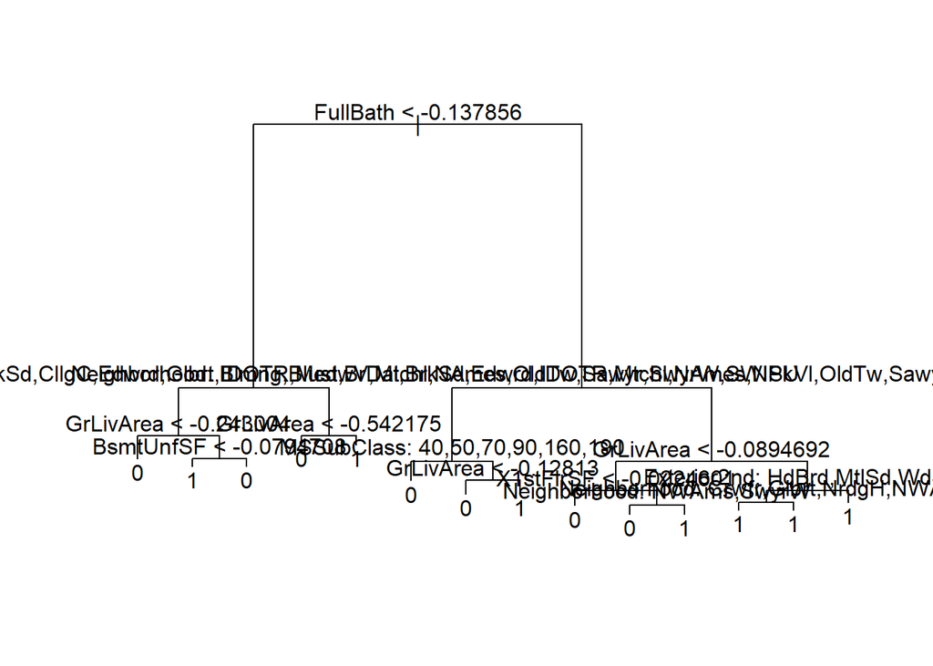

```r
#plot decsision tree
plot(tree.price)
text(tree.price,pretty=5)
```

```r
#accuracy for test:
#Predict using validation set
tree.pred=predict(tree.price,test2,type="class")
table(tree.pred,test2$Price)
```

```
##
## tree.pred   0   1
##         0 181  25
##         1  31 186
```

```r
(186+181) / (186+181+25+31)  # 0.8676
```

```
## [1] 0.8676123
```

```r
##Evaluation Metrics:
Accuracy(tree.pred, test2$Price) #0.8676123
```

```
## [1] 0.8676123
```

```r
AUC(tree.pred, test2$Price) #0.8676451
```

```
## [1] 0.8676451
```

```r
F1_Score(tree.pred, test2$Price, positive = NULL) #0.8660287
```

```
## [1] 0.8660287
```

```r
ConfusionMatrix(tree.pred, test2$Price)
```

```
##       y_pred
## y_true   0   1
##      0 181  31
##      1  25 186
```

- Cross Validation for Pruning:

```r
#Form tree using 10-fold cross validating and pruning
#misclassify a göre sýrala hangi node'un final node olacaðýný bulmak için

cv.price=cv.tree(tree.price,FUN=prune.misclass)

#names(cv.price)
cv.price
```

```
## $size
##  [1] 14 12 10  9  7  6  5  4  2  1
##
## $dev
##  [1] 109 111 108 106 116 117 125 125 141 502
##
## $k
##  [1]  -Inf   0.0   0.5   3.0   6.0   8.0  11.0  12.0  19.5 308.0
##
## $method
## [1] "misclass"
##
## attr(,"class")
## [1] "prune"         "tree.sequence"
```

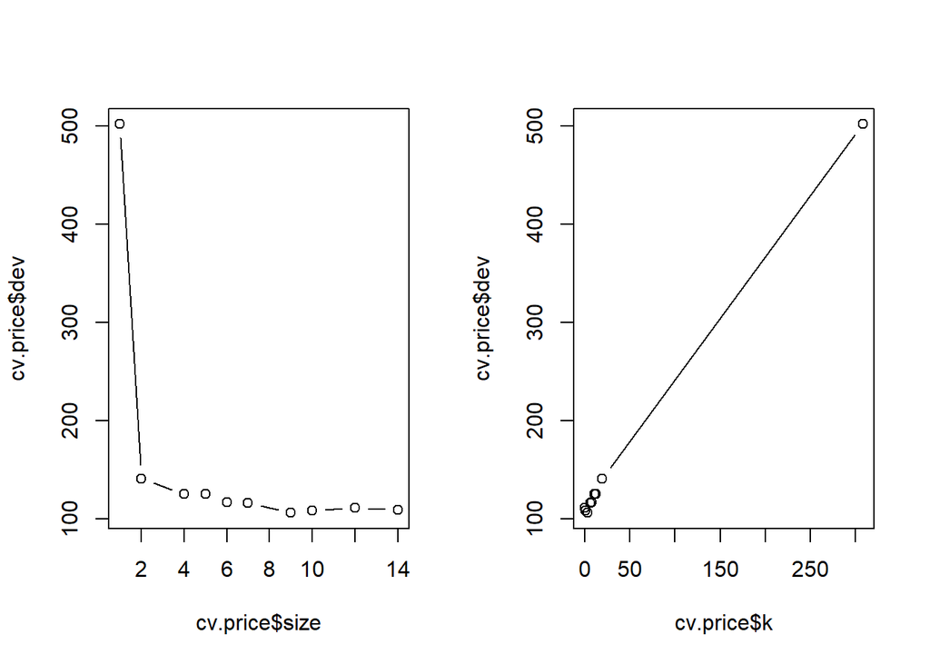

```r
#train dataset e CV yaparak kaç tane terminal node olması gerektiðini bulduk.
#dev: 106 =min ; size=9. 9 tane terminal node olmasý gerektiðini söyledi. Bunu parametre olarak vericez tree'ye.
par(mfrow=c(1,2))
plot(cv.price$size,cv.price$dev,type="b")
plot(cv.price$k,cv.price$dev,type="b")
```

9 is fine as Number of final node due to 10-Fold CV from tree library.

- Tree with the best node number:

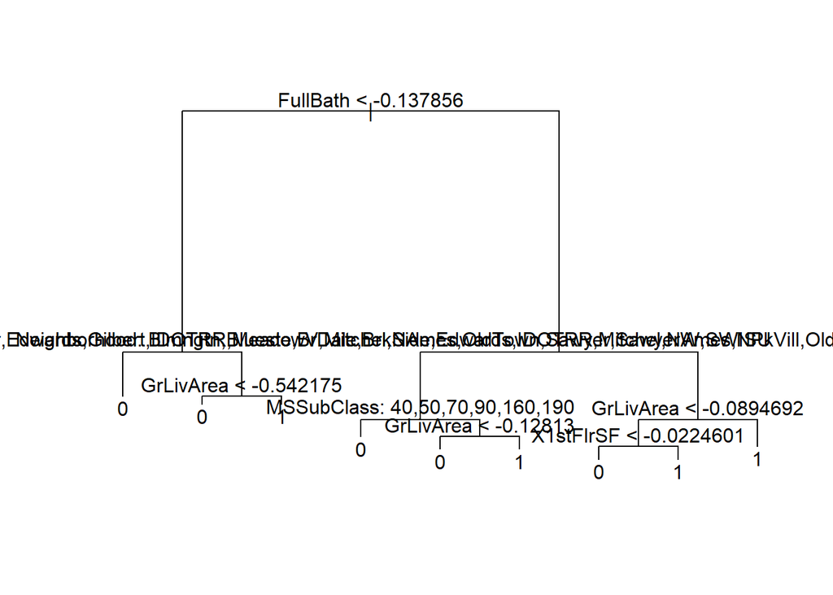

```r
prune.price=prune.misclass(tree.price,best=9) #elle giricez bulduðumuz deðeri yukarýda.
plot(prune.price)
text(prune.price,pretty=0) #pretty=1 bazý bilgileri gizler.
```

```r
tree.pred=predict(prune.price,test2,type="class")
table(tree.pred,test2$Price)
```

```
##
## tree.pred   0   1
##         0 185  22
##         1  27 189
```

```r
(189+185) / ((189+185+22+27)) #0.884
```

```
## [1] 0.8841608
```

```r
#plot(yhat,boston.test) actual pred grafiði.
#actual-predicted
summary(prune.price)
```

```
##
## Classification tree:
## snip.tree(tree = tree.price, nodes = c(15L, 4L, 29L))
## Variables actually used in tree construction:
## [1] "FullBath"     "Neighborhood" "GrLivArea"    "MSSubClass"
## [5] "X1stFlrSF"
## Number of terminal nodes:  9
## Residual mean deviance:  0.4725 = 428.1 / 906
## Misclassification error rate: 0.07104 = 65 / 915
```

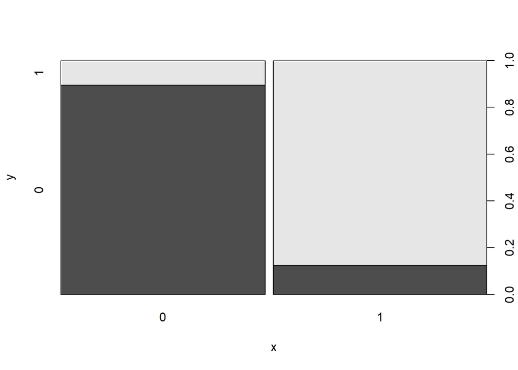

```r
plot(tree.pred,test2$Price)
```

```r
##Evaluation Metrics:
Accuracy(tree.pred, test2$Price) #0.8841608
```

```
## [1] 0.8841608
```

```r
AUC(tree.pred, test2$Price) # 0.8841881
```

```
## [1] 0.8841881
```

```r
F1_Score(tree.pred, test2$Price, positive = NULL) #0.8830549
```

```
## [1] 0.8830549
```

```r
ConfusionMatrix(tree.pred, test2$Price)
```

```
##       y_pred
## y_true   0   1
##      0 185  27
##      1  22 189
```

#### 2.3. RandomForest

- RandomForest with Categorical + Scaled Numeric Data

```r
library(randomForest)
data_tree <- data_wo_na

dim(data_tree)
```

```
## [1] 1338   69
```

```r
glimpse(data_tree)
```

```
## Observations: 1,338
## Variables: 69
## $ MSSubClass    <fctr> 60, 20, 60, 70, 60, 50, 20, 60, 50, 190, 20, 60...
## $ MSZoning      <fctr> RL, RL, RL, RL, RL, RL, RL, RL, RM, RL, RL, RL,...
## $ LotArea       <dbl> -0.16478521, 0.08222518, 0.38926824, 0.07211611,...
## $ Street        <fctr> Pave, Pave, Pave, Pave, Pave, Pave, Pave, Pave,...
## $ LotShape      <fctr> Reg, Reg, IR1, IR1, IR1, IR1, Reg, IR1, Reg, Re...
## $ LandContour   <fctr> Lvl, Lvl, Lvl, Lvl, Lvl, Lvl, Lvl, Lvl, Lvl, Lv...
## $ Utilities     <fctr> AllPub, AllPub, AllPub, AllPub, AllPub, AllPub,...
## $ LotConfig     <fctr> Inside, FR2, Inside, Corner, FR2, Inside, Insid...
## $ LandSlope     <fctr> Gtl, Gtl, Gtl, Gtl, Gtl, Gtl, Gtl, Gtl, Gtl, Gt...
## $ Neighborhood  <fctr> CollgCr, Veenker, CollgCr, Crawfor, NoRidge, Mi...
## $ Condition1    <fctr> Norm, Feedr, Norm, Norm, Norm, Norm, Norm, PosN...
## $ Condition2    <fctr> Norm, Norm, Norm, Norm, Norm, Norm, Norm, Norm,...
## $ BldgType      <fctr> 1Fam, 1Fam, 1Fam, 1Fam, 1Fam, 1Fam, 1Fam, 1Fam,...
```

[output cut: 56 more lines]

```r
data_tree$Price <- ifelse(data_tree$SalePrice>=median(data_tree$SalePrice),1,0)
data_tree$Price <- as.factor(data_tree$Price)


train2 <- data_tree %>% filter (data_tree$flag == 1 )
test2 <- data_tree %>% filter (data_tree$flag == 0 )

dim(test2)
```

```
## [1] 423  70
```

```r
train2 <- train2[ ,(!names(train2) %in% c('flag','SalePrice'))]
test2 <- test2[ ,(!names(test2) %in% c('flag','SalePrice'))]

dim(train2)
```

```
## [1] 915  68
```

```r
#RandomForest:
set.seed(1)
bag.price=randomForest(train2$Price~.,data=train2,mtry=7,importance=TRUE)
bag.price
```

```
##
## Call:
##  randomForest(formula = train2$Price ~ ., data = train2, mtry = 7,      importance = TRUE)
##                Type of random forest: classification
##                      Number of trees: 500
## No. of variables tried at each split: 7
##
##         OOB estimate of  error rate: 7.54%
## Confusion matrix:
##     0   1 class.error
## 0 426  29  0.06373626
## 1  40 420  0.08695652
```

```r
importance(bag.price) #treeleri göremediðimiz için relative importance larý görelim.
```

```
##                         0          1 MeanDecreaseAccuracy MeanDecreaseGini
## MSSubClass    12.77544384  8.0725546           13.4401891      13.99027977
## MSZoning       7.25809143  7.8291126            9.6118356       4.41892728
## LotArea       12.17184789 15.2106465           17.5054159      14.30364237
## Street         0.00000000  0.0000000            0.0000000       0.00000000
## LotShape       1.82507728  2.1499017            2.8460914       1.40759910
## LandContour   -0.71938875  1.1382810            0.2667692       0.59219867
## Utilities      0.00000000  0.0000000            0.0000000       0.02824122
## LotConfig      3.07470388  0.7102345            2.8626834       1.61772925
## LandSlope      2.47037542  0.5322771            2.0430621       0.58492095
## Neighborhood  25.26795957 12.2446652           24.1908357      49.24449545
## Condition1     1.71326099  2.0738181            2.7095655       1.71815914
## Condition2     1.00100150  0.0000000            1.0010015       0.07709637
## BldgType       7.53904641  5.4203509            8.2636324       2.51160101
## HouseStyle     5.33408601  4.9248360            7.0291927       3.56298796
## OverallQual   15.94716589 11.0742193           18.0244460      34.45091917
## OverallCond    0.72813000  4.5312952            3.4955867       3.51426373
## YearRemodAdd  11.76813694  8.7361724           12.2501714      13.30532959
## RoofStyle     -0.70553767  1.7668705            0.9349438       1.20568047
## RoofMatl       3.74818821 -0.7696935            2.8347066       0.76924789
## Exterior1st    5.06736981  7.4176051            8.6909121       6.22454751
## Exterior2nd    4.59570317  4.9241779            6.7250294       6.85233124
## MasVnrType     6.15711998  1.8830145            5.9972343       1.84282903
## MasVnrArea     8.01223391  2.9496895            8.4036809       3.85718822
## ExterQual     10.75201092  4.8623700           10.6486938      20.14172242
## ExterCond     -2.04091230  1.1388814            0.1720701       0.57208215
## Foundation     4.49844173  4.7537309            6.3036450       5.42264454
## BsmtQual       9.63235578  8.8855014           11.2007007      17.24719547
## BsmtCond       2.64515840 -1.5828228            1.9354211       0.42657126
## BsmtExposure   7.44985805  3.3473058            7.8432697       2.93971780
## BsmtFinType1   5.66393268  6.3013069            8.1626736       6.61485269
## BsmtFinSF1     9.47759174  2.0295467            8.9251897       5.47289183
## BsmtFinType2  -3.09416535  3.6537892           -0.8026707       1.88244869
## BsmtFinSF2     2.78210524  4.5046104            4.8535943       2.10095646
## BsmtUnfSF      5.61392738  4.9430151            7.3241185       5.83144623
## Heating        0.05809890 -1.7294947           -0.9652971       0.13693573
## HeatingQC      6.12326141  3.4579065            6.0820609       4.66747668
## CentralAir     2.74452294  3.4359495            3.8574254       0.36968148
## Electrical    -1.37590196  2.8707805            2.2238029       0.44924402
## X1stFlrSF     16.70098018 13.8410828           19.7577917      18.49864472
```

[output cut: 13 more lines]

```
## GarageFinish   7.48896832  5.2163126            7.9443443      12.03416466
## GarageCars     7.20740327  9.2296981           10.8237452       9.04811223
## GarageQual     0.89837735  2.2307310            2.2860237       0.43070283
## GarageCond    -1.46226355  3.2500268            1.8658404       0.36601472
## PavedDrive    -0.05553836  2.7042902            2.0184624       0.55985147
## WoodDeckSF     4.30246978  5.7669870            7.2294702       3.62641965
## OpenPorchSF   10.21807388  6.4784854           10.4253938      10.79206038
## EnclosedPorch  0.30803535  1.6426183            1.3315647       1.21773055
## X3SsnPorch    -0.51366882  0.5073096           -0.4628530       0.57933165
## ScreenPorch    2.23548673  1.8944831            2.8083495       1.05510482
## MiscVal       -1.34299978 -1.9753560           -2.3898695       0.19171905
## YrSold         0.95979344 -0.5534888            0.2548661       2.05854679
## SaleType       0.94040400  0.3599894            0.8483180       0.75083740
## SaleCondition  3.55951140  3.0905364            4.5817346       1.43428573
## Age           12.95921738  9.9414080           15.1280760      30.19749644
```

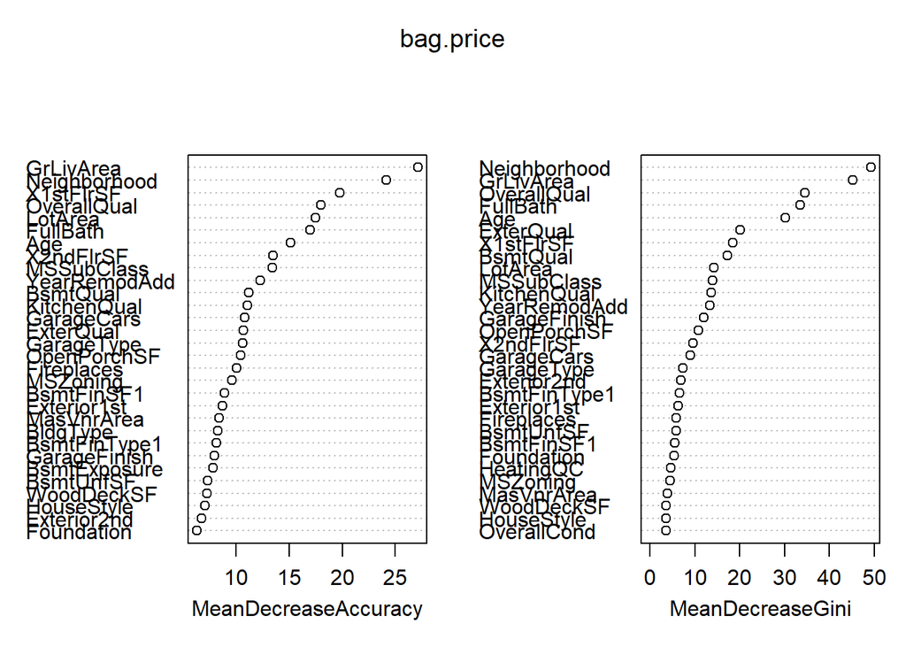

```r
#importance ne kadar yüksekse o kadar iyi.
varImpPlot(bag.price)
```

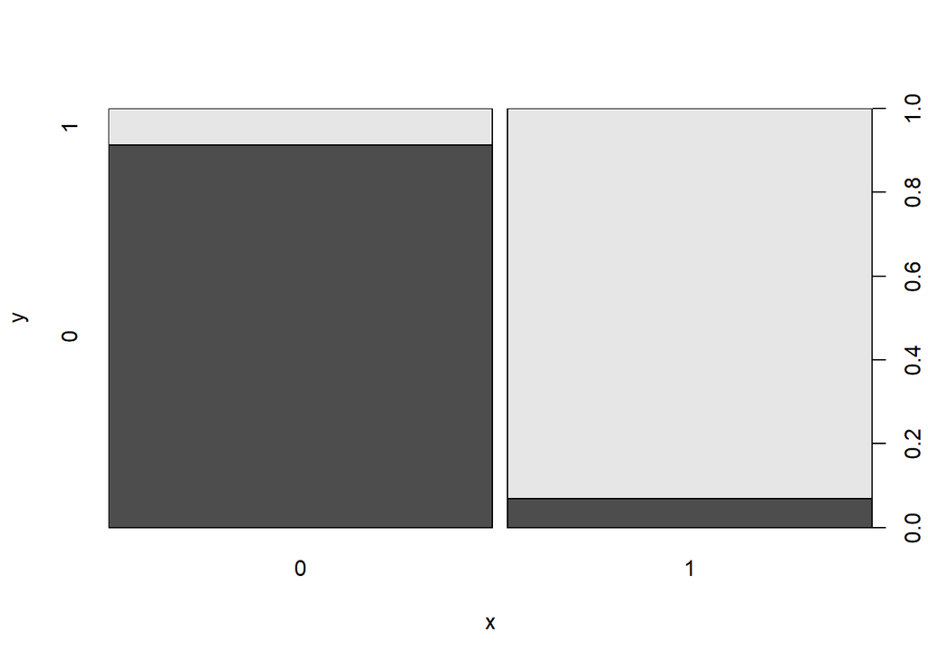

```r
#IncMSE grafiği en önemliden en aþaðýya diziyor. rm çýakrdýðýmýzda MSE ne kadar artacak diyerek onu en üse koyuyor.



yhat.bag = predict(bag.price,newdata=test2)
plot(yhat.bag, test2$Price)
```

```r
table(yhat.bag, test2$Price)
```

```
##
## yhat.bag   0   1
##        0 198  19
##        1  14 192
```

```r
(196+193) /(196+193+16+18)  #mtry=9 0.9196
```

```
## [1] 0.9196217
```

```r
(196+194)/ 423 # mtry=13 0.921
```

```
## [1] 0.9219858
```

```r
(198+192) / 423 # mtry=7 0.9219
```

```
## [1] 0.9219858
```

```r
##Evaluation Metrics:
Accuracy(yhat.bag, test2$Price) #0.9219858
```

```
## [1] 0.9219858
```

```r
AUC(yhat.bag, test2$Price) # 0.9219574
```

```
## [1] 0.9219574
```

```r
F1_Score(yhat.bag, test2$Price, positive = NULL) #0.9230769
```

```
## [1] 0.9230769
```

```r
ConfusionMatrix(tree.pred, test2$Price)
```

```
##       y_pred
## y_true   0   1
##      0 185  27
##      1  22 189
```

Random forests has 2 parameters: The first parameter is the same as bagging (the number of trees) The second parameter (unique to randomforests) is mtry which is how many features to search over to find the best feature. this parameter is usually 1/3*D for regression and sqrt(D) for classification. thus during tree creation randomly mtry number of features are chosen from all available features and the best feature that splits the data is chosen. The fundamental difference is that in Random forests, only a subset of features are selected at random out of the total and the best split feature from the subset is used to split each node in a tree, unlike in bagging where all features are considered for splitting a node.